# Clustering using R

Let us now see the customers in each of the clusters. We use the command *filter* along with specification of the cluster name. So for example *filter(clustering.vector, cluster == 1)* returns all rows that have cluster value as $1$, that is all customers who are in cluster $1$. For cluster $1$, we show the entire data set to give an understanding of easy to interpret how similar they are. Then we show the customer name alone for the corresponding cluster.

```r
cluster.show <- filter(clustering.vector, cluster == 1)

cluster.show ##give the entire set of columns based on filtered by cluster 1. This shows all transactions by the corresponding cluster. Note that there are 324 transactions between 100 customers.
```

```
##    Row.names customername 1 2 3 4 5 6 7 8 9 10 11 12 13 14 15 16 17 18 19
## 1         12     Campbell 0 1 0 0 0 0 0 0 0  0  0  0  0  0  0  0  0  0  0
## 2         12     Campbell 0 1 0 0 0 0 0 0 0  0  0  0  0  0  0  0  0  0  0
## 3         12     Campbell 0 1 0 0 0 0 0 0 0  0  0  0  0  0  0  0  0  0  0
## 4         16         Cook 0 0 0 0 0 0 0 0 0  0  0  0  0  0  0  0  0  0  0
## 5         16         Cook 0 0 0 0 0 0 0 0 0  0  0  0  0  0  0  0  0  0  0
## 6         18          Cox 0 1 0 0 0 0 0 0 0  0  0  0  0  0  0  0  1  0  0
## 7         18          Cox 0 1 0 0 0 0 0 0 0  0  0  0  0  0  0  0  1  0  0
## 8         18          Cox 0 1 0 0 0 0 0 0 0  0  0  0  0  0  0  0  1  0  0
## 9         18          Cox 0 1 0 0 0 0 0 0 0  0  0  0  0  0  0  0  1  0  0
## 10        25       Flores 0 0 0 0 0 0 0 0 0  0  0  0  0  0  0  0  1  0  0
## 11        25       Flores 0 0 0 0 0 0 0 0 0  0  0  0  0  0  0  0  1  0  0
## 12         3     Anderson 0 0 0 0 0 0 0 0 0  0  0  0  0  0  0  0  0  0  0
## 13         3     Anderson 0 0 0 0 0 0 0 0 0  0  0  0  0  0  0  0  0  0  0
## 14        30         Gray 0 0 0 0 0 0 0 0 0  0  0  1  0  0  0  1  0  0  0
```

[output cut: 117 more lines]

```r
cluster.show$customername ##gives just the customer name from the above.
```

```
##  [1] Campbell  Campbell  Campbell  Cook      Cook      Cox       Cox
##  [8] Cox       Cox       Flores    Flores    Anderson  Anderson  Gray
## [15] Gray      Gray      Jenkins   Jenkins   Johnson   Johnson   Johnson
## [22] Moore     Moore     Morris    Morris    Morris    Peterson  Peterson
## [29] Peterson  Peterson  Peterson  Peterson  Phillips  Phillips  Bell
## [36] Bell      Bell      Bell      Rodriguez Rodriguez Russell   Smith
## [43] Smith
## 100 Levels: Adams Allen Anderson Bailey Baker Barnes Bell ... Young
```

```r
## Similarly repeat for customer 2
cluster.show <- filter(clustering.vector, cluster == 2)
cluster.show$customername
```

```
##  [1] Adams     Adams     Adams     Brown     Brown     Brown     Carter
##  [8] Carter    Carter    Carter    Cruz      Cruz      Diaz      Diaz
## [15] Diaz      Diaz      Edwards   Edwards   Green     Gutierrez Gutierrez
## [22] Gutierrez Gutierrez Hernandez Hernandez Hill      Hill      Hill
## [29] Hill      Hughes    Hughes    Hughes    Hughes    Hughes    Bailey
## [36] Bailey    James     James     James     James     James     Jones
## [43] King      King      King      King      Lewis     Lewis     Lewis
## [50] Morgan    Morgan    Murphy    Murphy    Myers     Myers     Ortiz
## [57] Perez     Perez     Perry     Perry     Perry     Perry     Rivera
## [64] Rivera    Robinson  Robinson  Ross      Ross      Bennett   Bennett
## [71] Stewart   Stewart   Stewart   Sullivan  Sullivan  Sullivan  Taylor
## [78] Taylor    Taylor    Taylor    Torres    Walker    Walker    Watson
## [85] Watson    Wilson    Wilson
## 100 Levels: Adams Allen Anderson Bailey Baker Barnes Bell ... Young
```

```r
## Similar for customer 3
cluster.show <- filter(clustering.vector, cluster == 3)
cluster.show$customername
```

```
##   [1] Butler   Butler   Butler   Butler   Butler   Clark    Clark
##   [8] Clark    Clark    Collins  Collins  Cooper   Cooper   Cooper
##  [15] Cooper   Allen    Allen    Davis    Davis    Davis    Fisher
##  [22] Fisher   Fisher   Fisher   Fisher   Fisher   Fisher   Foster
##  [29] Foster   Foster   Foster   Foster   Garcia   Garcia   Gomez
##  [36] Gomez    Gomez    Gomez    Hall     Hall     Howard   Howard
##  [43] Howard   Jackson  Jackson  Jackson  Jackson  Jackson  Lopez
##  [50] Lopez    Lopez    Lopez    Lopez    Martin   Martin   Martin
##  [57] Martinez Martinez Martinez Mitchell Mitchell Parker   Parker
##  [64] Parker   Parker   Parker   Powell   Ramirez  Reed     Reed
##  [71] Reyes    Reyes    Sanchez  Sanchez  Sanchez  Sanchez  Sanchez
##  [78] Sanchez  Sanchez  Sanders  Sanders  Sanders  Sanders  Sanders
##  [85] Sanders  Sanders  Sanders  Sanders  Thomas   Thomas   Thomas
##  [92] Thomas   Thomas   Thomas   Thompson Thompson Thompson Thompson
##  [99] Brooks   Brooks   Brooks   Brooks   Ward     White    White
## [106] White    White
## 100 Levels: Adams Allen Anderson Bailey Baker Barnes Bell ... Young
```

```r
## Similar for customer 4
cluster.show <- filter(clustering.vector, cluster == 4)
cluster.show$customername
```

```
##  [1] Young      Young      Young      Young      Young      Young
##  [7] Evans      Evans      Gonzalez   Gonzalez   Harris     Harris
## [13] Harris     Harris     Harris     Harris     Kelly      Kelly
## [19] Kelly      Kelly      Lee        Lee        Lee        Lee
## [25] Lee        Long       Long       Long       Baker      Baker
## [31] Baker      Baker      Miller     Miller     Miller     Miller
## [37] Miller     Miller     Miller     Morales    Morales    Morales
## [43] Morales    Morales    Morales    Barnes     Barnes     Barnes
## [49] Barnes     Nelson     Nelson     Nelson     Nelson     Nguyen
## [55] Nguyen     Price      Price      Price      Price      Richardson
## [61] Richardson Richardson Roberts    Rogers     Rogers     Rogers
## [67] Rogers     Rogers     Rogers     Scott      Scott      Scott
## [73] Turner     Turner     Turner     Turner     Williams   Williams
## [79] Williams   Wood       Wood       Wood       Wood       Wright
## [85] Wright     Wright     Wright
## 100 Levels: Adams Allen Anderson Bailey Baker Barnes Bell ... Young
```

The above commands give us a good sense of the customers who were in different clusters, thus helping the business decisions. It gives a simple way to understand the features that make them similar.

## Within cluster estimates

Recall that we also calculated within cluster sum of squares to get an understanding of their fit. *kmeans* also returns variable *withinss* with the corresponding values. That is to get the vector of with-in cluster of the sum of squares, use the *$withinss* value that is returned. This returns sum of squares as one component per cluster. This is accessed using the following command.

```r
kmeans.result$withinss
```

```
## [1] 19.31 51.39 83.38 58.95
```

# Advanced – Graphics and Silhouette

In the following section, we will discuss some graphics option as to how would one would plot the output from the clusters. These commands are somewhat advanced, but give a sense of the options available in R. The key to note is that amount of code that is needed to get the output. Usually it is few lines that give you robust set of results while prototyping.

## Plotting output

First let us install the packages that we would need for graphics options. We illustrate two different methods of plotting the output, and include two packages that are specifically used for this purpose. If you dont have the packages already installed, run the following two lines of code to install and then load them. If you are running the .Rmd file, replace *{r eval = FALSE}* with *{r}* .

```r
install.packages('cluster')
devtools::install_github("sinhrks/ggfortify")
```

Using the *cluster* package.

```r
library(cluster)
```

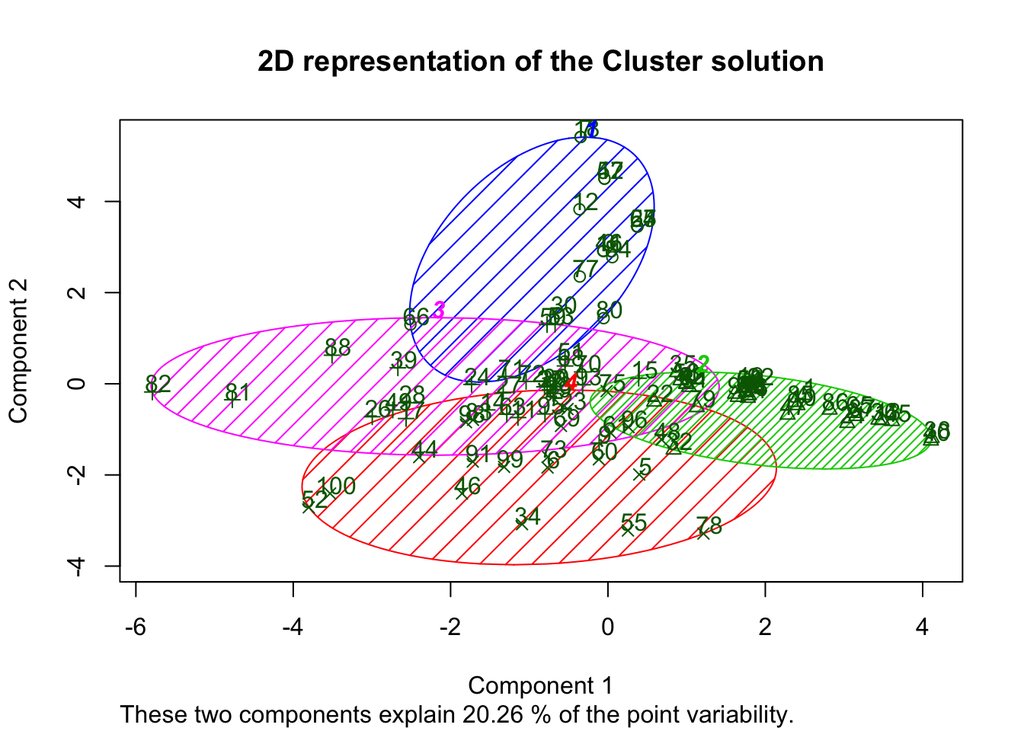

```r
clusplot(clustering.vector.inp, kmeans.result$cluster, main='2D representation of the Cluster solution', color=TRUE, shade=TRUE, labels=2, lines=0)
```

Using the *ggfortify* package.

```r
library(ggfortify)
```

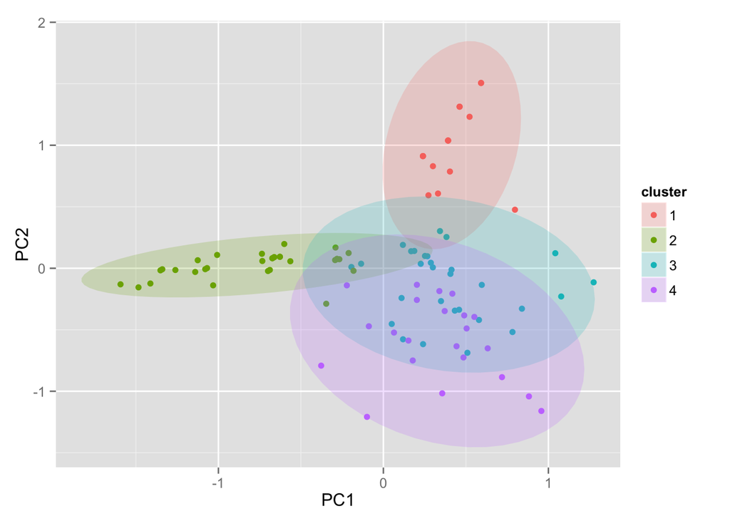

```r
autoplot(kmeans.result, data=clustering.vector.inp, frame=TRUE, frame.type='norm')
```

## Silhouetting

In the next step, we run the *kmeans* algorithm multiple times and see how the silhouette value looks like. This will help us to give an idea of the $K$ that we would pick. We repeat this for all values from $2$ to $10$. That is we see the siluoette values for each cluster between $2$ to $10$.

We run the program in the form of a loop using the *for* statement in R. The following statement illustrates a loop. In this case, the program runs the code between the pair of { and }, for each value of $i$ from $2$ to $MAX$.

```r
for (i in 2:MAX) ##run the loop from 2 to MAX. i value gets incremented in each iteration.
```

The idea in our case is that we run *kmeans* algorithm for number of clusters = $2$, calculate the silouette value. Then we run the program for number of cluster = $3$, calculate the silhouette value, and we keep repeating this for all values until $MAX$. In our case, we set $MAX$ to $10$ but that can be changed to any value. In that way, one can evaluate what would be a good cluster to pick from between $2$ and $10$ depending on the silhouette value.

```r
MAX <- 10 #Maximum number of clusters to try
sil <- NULL

for (i in 2:MAX) #Loop runs for all value of i between 2 and MAX.
{
      temp.kmeans <- kmeans(clustering.vector.inp,
                            centers=i) #Performs K-means clustering for the corresponding value of i.

      temp.clusters <- temp.kmeans$cluster #get the clusters from the output.

      temp.silval <- silhouette(temp.clusters,
                                dist(clustering.vector.inp)) # calculate the silhouette value and store it in the temp.silval.

      sil[i] <- mean(temp.silval[,3]) #store the mean silhouette value that is used for plotting the value in the next step.
}
```

## Plotting the silhouette values

Finally, plot the silhouette values that was created in the previous step:

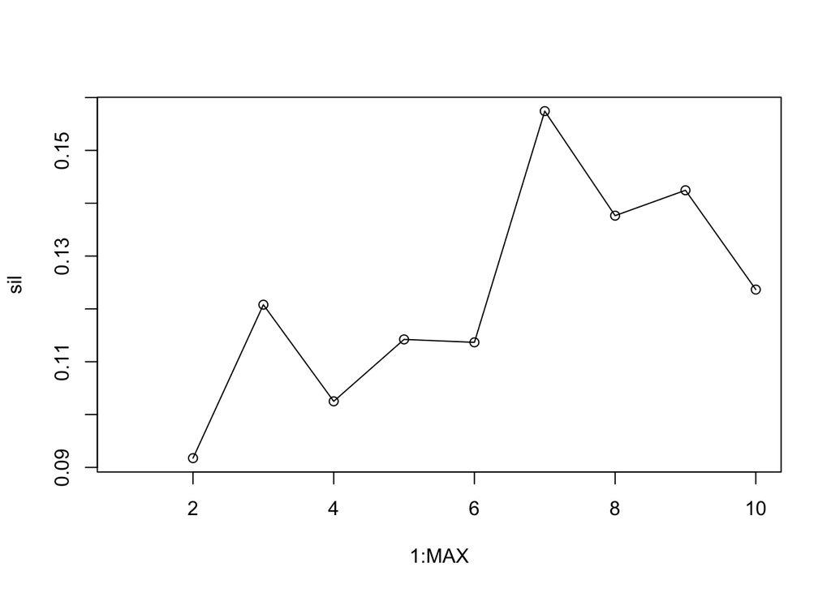

```r
plot(1:MAX, sil)
lines(1:MAX, sil)
```